# 22100 - R for Bio Data Science

2022-05-09

## Introduction

- Data
  - Open-source: https://doi.org/10.1371/journal.pmed.1003489
- Control study: PancRISK
  - Blood biomarker; plasma_CA19_9
  - Urinary biomarkers; REG1A, REG1B, LYVE1, TFF1
  - Normalization; creatinine and age
  - Diagnosis; control, benign, malignant
- Aim
  - Visual exploration
  - Urinary biomarker performance
  - Evaluation of diagnosis prediction

## Materials and Methods

### Flow chart

[figure not shown]

## Materials and Methods

### Data Visualization

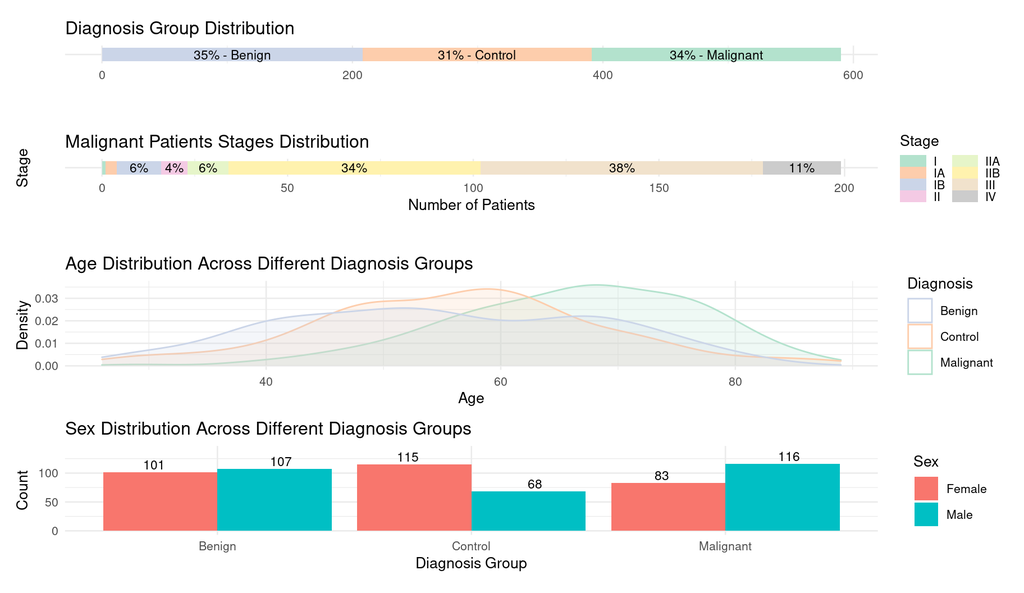

## Materials and Methods

### Data Visualization

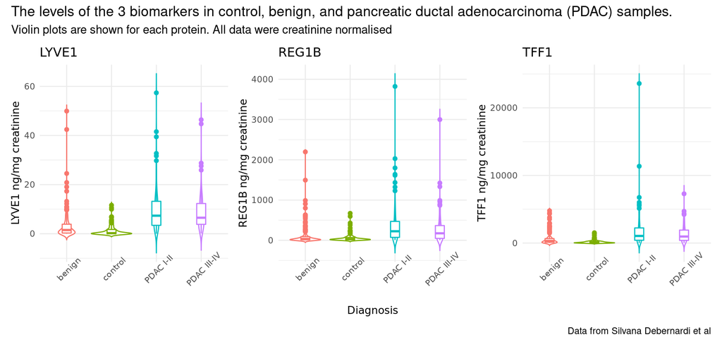

## Materials and Methods

### Data modelling

- 1:1 Training- and validation-set split
- Seperate/Multinomial logistic regression (glm)
- Candidate 1: binary plasma CA19_9 (cutoff 37 U/ml)
- Cand. 2 (Old panel): REG1A, LYVE1, TFF1; corrected for age and creatinine
- Cand. 3 (without plasma): REG1B, LYVE1, TFF1; corrected for age and creatinine
- Cand. 4 (PancRISK): REG1B, LYVE1, TFF1 and binary plasma CA19_9; corrected for age and creatinine

## Results

### PCA & K-means

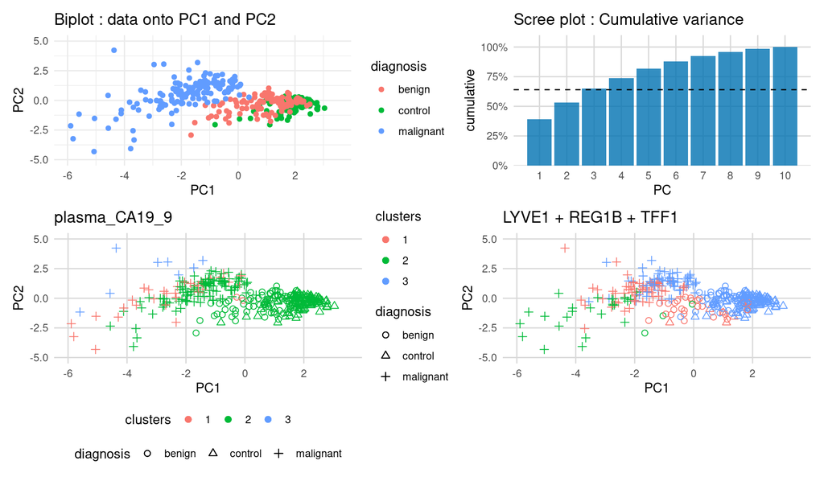

## Results

### Data modelling

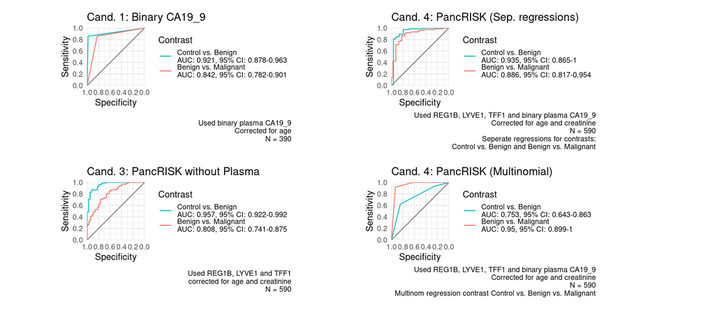

## Results

### Data modelling

| Performance - Cand. 1: Binary CA19_9 Accurancy | Performance - Cand. 1: Binary CA19_9 0.914 95% CI: 0.855 - 0.955 Control vs. Malignant | Performance - Cand. 1: Binary CA19_9 0.842 95% CI: 0.773 - 0.897 Benign vs. Malignant |
| --- | --- | --- |
| Sensitivity | 0.826 | 0.984 |
| Specificity | 0.857 | 0.857 |

| Performance - Cand. 2: Old panel Accurancy | Performance - Cand. 2: Old panel 0.634 95% CI: 0.52 - 0.738 Control vs. Malignant | Performance - Cand. 2: Old panel 0.857 95% CI: 0.753 - 0.929 Benign vs. Malignant |
| --- | --- | --- |
| Sensitivity | 0.857 | 0.789 |
| Specificity | 0.857 | 0.587 |

| Performance - Cand. 3: PancRISK without Plasma Accurancy | Performance - Cand. 3: PancRISK without Plasma 0.734 95% CI: 0.658 - 0.801 Control vs. Malignant | Performance - Cand. 3: PancRISK without Plasma 0.886 95% CI: 0.82 - 0.935 Benign vs. Malignant |
| --- | --- | --- |
| Sensitivity | 0.923 | 0.769 |
| Specificity | 0.871 | 0.710 |

| Performance - Cand. 4: PancRISK (Sep. regression) Accurancy | Performance - Cand. 4: PancRISK (Sep. regression) 0.848 95% CI: 0.768 - 0.909 Control vs. Malignant | Performance - Cand. 4: PancRISK (Sep. regression) 0.853 95% CI: 0.769 - 0.915 Benign vs. Malignant |
| --- | --- | --- |
| Sensitivity | 0.966 | 0.821 |
| Specificity | 0.808 | 0.863 |

## Discussion

Blood vs Urinary diagnosis classification :

1) K-means based on urinary bio-markers slightly better than the one based on plasma_CA19_9

2) Blood plasma shows importance in classification during the multinational logistic regression

Possible explanation:

1) Patients with malignant diagnosis should be subdivided into stages to improve the classification performance.

Further research aim:

Discovery of new urinary bio-markers could provide a non invasive diagnosis with better diagnosis accuracy